# Sustainability Analytics: Project Report Group 2

Effect of Climate Change on Great Aletsch Glacier and the village of Brig

Vani Gupta

Hochschule Luzern  
vani.gupta@stud.hslu.ch

Ramona Kölliker

Hochschule Luzern  
ramona.kölliker@stud.hslu.ch

Valérie Lüthi

Hochschule Luzern  
valerie.lüthi@stud.hslu.ch

Alois Wagner

Hochschule Luzern  
alois.wagner@stud.hslu.ch

2025-09-05

Link to GitHub Repo: SustainabilityAnalytics_FS25_Team3

**Loading R-Packages**

```r
#Loading needed packages
library(dplyr)
library(forecast)
library(ggplot2)
library(lubridate)
library(tidyr)
library(tseries)  # for working with time series
library(urca)     # for performing ADF unit root test
library(ismev)    # for EVT gev.fit
library(tidyverse)# for data handling (includes ggplot2, dplyr, tidyr, readr, lubridate)
library(evd)      # for calculating HQ values in EVT
library(zoo)      # for function 'yearmon'
set.seed(1234)
```

# 1 Introduction

The United Nations declared the year 2025 as the “International Year of Glaciers Preservation” to raise global awareness about the critical role of glaciers in the climate system and the hydrological cycle as well as the economic, social and environmental impacts of the impending changes ([UN](https://www.un-glaciers.org/en)). In alignment with this initiative, this report provides a sustainability analysis of the Aletsch Glacier, the largest glacier in the Alps. The focus lies on the Glaciers impact on the Massa river and the downstream communities in the Canton of Valais, particularly the town of Brig. The Aletsch Glacier`s meltwater feeds the Massa River, which joins the Rhone near Brig. While increased melting can temporarily increase flood risk, the long-term loss of glacier mass threatens to reduce water availability, impacting both the local population and hydropower generation.

This report aims to analyze these risks by developing a forecasting system. This system links climate change indicators to the Aletsch Glacier’s mass changes and subsequently to the waterlevel, watervolume and extreme flow events of the Massa and Rhone rivers.

The forecasting framework is intended to support:

- Early warning systems
- Infrastructure and land-use planning
- Resilient water and energy management

The goal is to provide local communities and stakeholders with the necessary information to prepare for future challenges in flood risk and water availability.

## 1.1 Research Question

How might we analyze the impact of climate change on the river levels of Massa for the Canton Valais so that the people of Brig can better prepare themselves for future changes in flood risk and water availability?

To answer this question, our analysis is divided into three components:

- Climate-Glacier Model: We use an ARIMAX model with annual data to link climate variables (temperature and precipitation) to glacier mass balance to forecast long-term ice loss
- Climate-River Model (Monthly): We use a SARIMAX model with monthly data linking climate variables (temperature and precipitation) to river discharge to gain insights for wate rmanagement
- Extreme Value Theory (EVT): EVT will be used to quantify the probability of extreme events, such as flooding, providing critical information for climate risk assessment and the development of preparedness strategies.

## 1.2 Alignment with UN Sustainable Development Goals (SDGs)

This project contributes to several of the UN`s [SDGs](https://www.un.org/sustainabledevelopment/sustainable-development-goals/), particularly:

- SDG 13: Climate Action Modeling glacier and hydrological changes to inform climate risk reduction and resilience planning.
- SDG 7: Affordable and Clean Energy Evaluating hydropower reliability under changing water availability for better seasonal energy planning.
- SDG 12: Responsible Consumption and Production Promoting efficient water resource and risk-aware infrastructure management.
- SDG 15: Life on Land Assessing ecosystem and habitat impacts from altered river flow regimes to support regional conservation efforts.
- SDG 6: Clean Water and Sanitation Providing insights into long-term water availability and its management for human and ecological needs.

## 1.3 Engaging the stakeholders

Effective stakeholder collaboration is critical to ensuring actionable and locally relevant outcomes. We have identified three key stakeholder groups with varying levels of influence and interest.

- Residents of Brig: Affected by flooding, water shortages, infrastructure resilience and overall quality of life.
- Hydropower operators (Massa River Dam): Dependent on predictable inflows for energy production and meeting regulatory standards.
- Cantonal authorities (Canton of Valais): Responsible for safety planning, data governance, and alignment with environmental policy and sustainability goals.

We conducted a Power–Interest Mapping to better understand the roles, motivations, and potential contributions of key stakeholders. This analysis helps guide our engagement strategies, ensuring that each group is involved in a way that reflects both their influence over outcomes and their level of interest in the project’s results.

| Stakeholder | Role | Motivation | Contribution to Project | Benefits from Project |
| --- | --- | --- | --- | --- |
| **Residents of Brig** | Land-use choices, emergency planning, public communication. | Flood safety, insurance costs, quality of life, tourism. | Local flood history, identification of critical sites (schools, homes), preferred warning channels. | Actionable risk information (timing, location), early-warning, guidance on adaptation measures. |
| **Massa River Dam & Hydropower Operators** | Flow regulation, reservoir level management, water release rules, maintenance. | Safety, regulatory compliance, energy yield, reputational risk. | Historical inflow/outflow data, operational rules, details of spill events. | scenarios for inflow/outflow, spill/shortage probabilities, data for decision support. |
| **Canton (Valais) Authorities** | Permits coordination, data governance, funding. | Regional safety, alignment with cantonal plans and SDGs. | Previous studies, regional hazard maps, legal standards. | Reproducible datasets, briefing materials for policymakers. |

- Dam Operators: High Power / High Interest -> Engage closely those managing the Massa River dam, are identified as having both high power and high interest. These operators play a critical role in water flow regulation and reservoir management, giving them significant influence over how the system responds to changing water availability. Moreover, their operational success is directly tied to reliable inflows, safety protocols, and regulatory compliance—all of which are affected by glacial melt and river dynamics. Because of this dual significance, it is essential to engage hydropower operators closely throughout the project, involving them in data sharing, scenario planning, and the development of risk management tools that align with both energy production and safety concerns.
- Canton Authorities: High Power / Medium-High Interest -> Collaborate & align Cantonal authorities in Valais, who oversee regional infrastructure, environmental planning, and public safety, also hold high power in terms of policy-making and resource allocation. However, their level of interest, while substantial, may be more medium-to-high, given their broader set of responsibilities across the region. These authorities are key partners for aligning our work with existing development plans and legal standards, and for ensuring that the project contributes meaningfully to regional sustainability goals. Therefore, the recommended engagement strategy with cantonal officials is one of active collaboration and strategic alignment, ensuring that their policy expertise and governance frameworks are fully integrated into the project outcomes.
- Residents: Medium Power / High Interest -> Empower through co-design the residents of Brig, although they may not possess the formal authority of institutions, exhibit high interest in the project due to their direct exposure to flood risk, water shortages, and changes to infrastructure resilience. Their power to influence high-level decision-making is moderate, but their lived experience, local knowledge, and community preferences are invaluable in designing practical and accepted solutions. For this reason, it is crucial to empower residents through participatory approaches, such as co-design workshops, transparent communication, and mechanisms for incorporating public feedback. Engaging them meaningfully helps build trust, improves the relevance of proposed measures, and ensures that risk communication strategies are well-targeted and effective.

## 1.4 System Dynamics: Causal Loop Modelling

To understand the complex and interconnected nature between climate, glaciers, hydrology and society, we created a causal loop diagram in Loopy. It models how glacier fed river dynamics affect flood risk and community resilience in Brig.

**Loopy_Model**

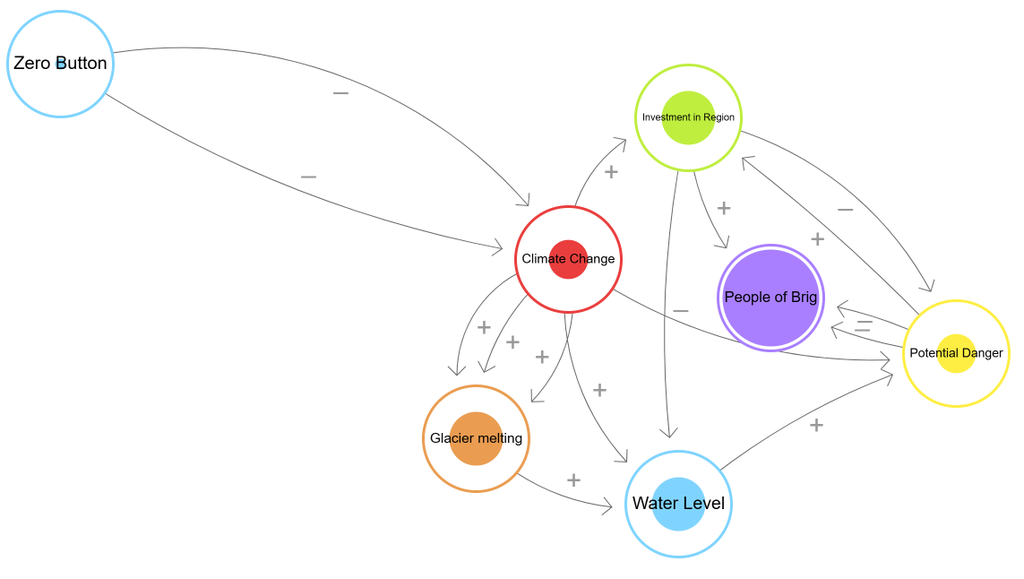

```r
knitr::include_graphics('../data/raw/Loopy_Model.png')
```

Link to Loopy Model

The diagram visualizes the relationships between our key variables: Climate Change, Glacier Melting, Water Level, Potential Danger, People of Brig and Investment in Region. Within the model, two critical types of variables are identified: stocks and flows. Stocks refer to the quantities that accumulate or deplete over time. In this context, they include the mass of the Aletsch Glacier, as well as the population exposed to flood risk in Brig. Flows, on the other hand, represent the rates at which changes occur in these stocks. For the glacier system, the most important flows are the melt rate of the glacier, the volume of river discharge, and the amount of incoming precipitation. These influence both the water level in the river and the rate at which the glacier’s mass is lost. Driving the entire system are exogenous variables—factors that originate outside the system but have a powerful influence on it. Chief among these is climate change, represented through observable trends in temperature increases and changes in precipitation patterns. These climate drivers accelerate glacier melting, alter the seasonal distribution of water flow, and intensify the risk of extreme events such as flooding.

The key feedback loops are:

- Climate-Melt-Danger: Climate change (rising temperature) positively influences glacier melting, which in turn increases the water level. This directly leads to a higher potential danger (flooding).
- Risk-induced Migration: Increased potential danger from flooding can negatively impact the population of Brig, potentially leading to out-migration, which in turn reduces the number of people exposed to the danger.
- Adaptation: An increase in potential danger can spur investments in protective measures (e.g. flood defenses), which then reduces the potential danger.
- Diminishing Glacier Source: Glacier melting is a key positive driver for water levels, but this process also reduces the glacier’s total mass (a stock variable). ultimately leading to diminished meltwater contributions and water scarcity over time.

# 2 Datapreparation/Cleaning

This analysis combines several complementary datasets to investigate hydrological dynamics in the Aletsch/Brig region. For the analysis we used the following datasets:

- Glacier Mass Balance - Seasonal and annual mass balance measurements of the Grosser Aletschgletscher
- Jungfraujoch Temperature - Monthly air temperature from the high-alpine Jungfraujoch station
- Brig Rainfall - Monthly precipitation totals from Brig weather station
- Massa River - Daily hydro-meteorological observations of Massa River
- Rhone River - Daily hydro-meteorological observations of Massa River

A detailed explanation of glacier mass balance and hydro-meteorological river data can be found in the feature explanation in the appendix.

**Loading Data**

```r
# Reading in data
raw_massa <- read.csv('../data/raw/massa_CAMELS_CH_obs_based_2161.csv', header=TRUE, sep=',', na.strings='-')
raw_rhone <- read.csv('../data/raw/brig_CAMELS_CH_obs_based_2346.csv', header=TRUE, sep=',', na.strings='-')
raw_glacier <- read.csv('../data/raw/massbalance_observation.csv', header=TRUE, sep=';', na.strings='-')
raw_jungfraujoch <- read.csv("../data/raw/weather_monthly_jungfraujoch.csv", header=TRUE, sep=';', na.strings='-')
raw_brigrain <- read.csv('../data/raw/weather_rain_monthly_brig.csv', header=TRUE, sep=';', na.strings='-')
```

## 2.1 Jungfraujoch Temperature

The homogeneous data series from the Jungfraujoch climate station is available on demand via [MeteoSchweiz OpenData](https://www.meteoswiss.admin.ch/services-and-publications/service/open-data.html). The station is located 3571 meters above sea level and located in the Aletsch area. We were interested in the measurement of the homogeneous monthly mean temperature covering the time span from 01/01/1933 to 01/07/2025. The temperature in Celsius was measured 2 meters above ground.

The raw Jungfraujoch weather data set was prepared by first converting the reference_timestamp column into a proper datetime format. Then the data set was reduced to the columns necessary for our analysis (station_abbr, reference_timestamp, temp_mean_C). For clarity columns were renamed. A check for missing values, confirmed that there were none. Then a time series object of the mean temperature values was created, specifying the start and end dates as well as the monthly frequency.

**data preparation for jungfraujoch**

```r
# convert timestamp to datetime format
df_jungfraujoch <- raw_jungfraujoch %>%
  mutate(reference_timestamp = dmy_hm(reference_timestamp))
# only keep columns needed for analysis
df_jungfraujoch_reduced <- df_jungfraujoch %>%
  select(station_abbr, reference_timestamp, ths200m0)
# rename columns
colnames(df_jungfraujoch_reduced) <- c('station_abbr', 'reference_timestamp', 'temp_mean_C')
# check for NAs
colSums(is.na(df_jungfraujoch_reduced)) # no NAs
# create time series object
# temp_mean monthly series
ts_jungfraujoch <- ts(df_jungfraujoch_reduced$temp_mean_C,
                      start = c(1933, 1),
                      end = c(1933 + (nrow(df_jungfraujoch_reduced)-1) %/% 12,
                              (nrow(df_jungfraujoch_reduced)-1) %% 12 + 1),
                      frequency = 12)

# create a year column
df_jungfraujoch_year <- df_jungfraujoch_reduced %>%
  mutate(Year = year(reference_timestamp))

# aggregate to annual mean
df_jungfraujoch_annual <- df_jungfraujoch_year %>%
  group_by(station_abbr, Year) %>%
  summarise(temp_mean_C = mean(temp_mean_C, na.rm = TRUE), .groups = "drop")

# convert to ts object
ts_jungfraujoch_annual <- ts(df_jungfraujoch_annual$temp_mean_C,
                             start = min(df_jungfraujoch_annual$Year),
                             end = max(df_jungfraujoch_annual$Year),
                             frequency = 1)
```

Additionally for later use in the annual Climate-Glacier model an annual time series was created by aggregating the monthly values to annual mean values.

**data preparation (annual aggregation) for jungfraujoch**

```r
# create a year column
df_jungfraujoch_year <- df_jungfraujoch_reduced %>%
  mutate(Year = year(reference_timestamp))

# aggregate to annual mean
df_jungfraujoch_annual <- df_jungfraujoch_year %>%
  group_by(station_abbr, Year) %>%
  summarise(temp_mean_C = mean(temp_mean_C, na.rm = TRUE), .groups = "drop")

# convert to ts object
ts_jungfraujoch_annual <- ts(df_jungfraujoch_annual$temp_mean_C,
                             start = min(df_jungfraujoch_annual$Year),
                             end = max(df_jungfraujoch_annual$Year),
                             frequency = 1)
```

## 2.2 Glacier

The data is sourced from Glacier Monitoring in Switzerland (GLAMOS). Direct measurements of glacier mass balance – the sum of snow accumulation and snow/ice melt – are carried out on selected glaciers in Switzerland, based on point observations, typically acquired in April/May and September.

For clarity, unnecessary columns were removed and the others were renamed. We were interested in information specifically regarding “Grosser Aletschgletscher” hence the dataset was filtered to just the relevant rows. We converted the date columns into proper datetime format. A check for missing values, confirmed that there were none.

**data preparation for glacier**

```r
## remove unwanted columns
df_glacier <- raw_glacier %>%
  select(-c("glacier.id", "observer", "X", "X.1", "X.2", "minimum.elevation.of.glacier", "maximum.elevation.of.glacier" ))
## rename columns to standard format
colnames(df_glacier) <- c("glacier_name", "obs_start_date", "obs_winter_end_date", "obs_end_date", "winter_mass_balance_mmwe",
                          "summer_mass_balance_mmwe", "annual_mass_balance_mmwe","equilibrium_line_altitude_m",
                          "accumulation_area_ratio", "glacier_area_m2")
## filter out rows of unwanted glaciers
df_glacier <- df_glacier %>%
  filter(glacier_name == "Grosser Aletschgletscher")
## convert relevant columns to date type values
df_glacier <- df_glacier %>%
  mutate(across(c(obs_start_date, obs_winter_end_date, obs_end_date),
                ~ as.Date(.x, format = "%d.%m.%Y")))
## check for NAs
colSums(is.na(df_glacier))

# create time series object for annual glacier mass balance
df_glacier_annual <- df_glacier %>%
  mutate(Year = year(obs_end_date)) %>%
  group_by(Year) %>%
  summarise(
    annual_mass_balance_mmwe = mean(annual_mass_balance_mmwe, na.rm = TRUE),
    .groups = "drop"
  ) %>%
  arrange(Year)

head(df_glacier_annual)

# create time series object
ts_glacier_annually <- ts(
  df_glacier_annual$annual_mass_balance_mmwe,
  start = min(df_jungfraujoch_annual$Year, na.rm = TRUE),
  end = max(df_glacier_annual$Year, na.rm = TRUE),
  frequency = 1
)

ts_glacier_annually
```

In order to perform correlation analysis, the bi-annual mass balance values were extrapolated to monthly values using weighted averages derived from the Jungfraujoch temperature data.

**data preparation (monhtly aggregation) for glacier**

```r
## Function to allocate seasonal mass balance by fixed calendar seasons
allocate_mass_balance_per_year <- function(row, df_jungfraujoch_reduced){

  obs_year <- year(row$obs_start_date)  # Observation year for this glacier row
  # Add helper columns
  df_jungfraujoch_reduced <- df_jungfraujoch_reduced %>%
    mutate(
      year_num = year(reference_timestamp),
      month_num = month(reference_timestamp),
      year_month = format(reference_timestamp, "%Y-%m"),
      temp_mean_C = as.numeric(temp_mean_C)
    )

  ## Winter months: Oct–Dec from previous year, Jan–Apr from current observation year
  winter_climate <- df_jungfraujoch_reduced %>%
    filter((month_num %in% 10:12 & year_num == (obs_year - 1)) |
             (month_num %in% 1:4 & year_num == obs_year))

  winter_weights <- abs(winter_climate$temp_mean_C)
  if(sum(winter_weights) == 0) winter_weights <- rep(1/nrow(winter_climate), nrow(winter_climate))
  winter_weights <- winter_weights / sum(winter_weights)
  winter_alloc <- winter_weights * row$winter_mass_balance_mmwe

  ## Summer months: May–Sep of current observation year
  summer_climate <- df_jungfraujoch_reduced %>%
    filter(month_num %in% 5:9 & year_num == obs_year)

  summer_weights <- abs(summer_climate$temp_mean_C)
  if(sum(summer_weights) == 0) summer_weights <- rep(1/nrow(summer_climate), nrow(summer_climate))
  summer_weights <- summer_weights / sum(summer_weights)
  summer_alloc <- summer_weights * row$summer_mass_balance_mmwe

  ## Combine summer and winter calculations
  dates <- c(winter_climate$year_month, summer_climate$year_month)
  alloc <- c(winter_alloc, summer_alloc)

  ## Return monthly allocation
  data.frame(
    year_month = dates,
    month = c(winter_climate$month_num, summer_climate$month_num),
    mass_balance_monthly = alloc
  )
}

## Construct df_glacier_monthly
df_glacier_monthly <- bind_rows(lapply(1:nrow(df_glacier), function(i){
  allocate_mass_balance_per_year(df_glacier[i, ], df_jungfraujoch_reduced)
}))

head(df_glacier_monthly,20)
```

## 2.3 Massa River

The data is freely available from the official CAMELS-CH publication [CAMELS-CH](https://essd.copernicus.org/articles/15/5755/2023/essd-15-5755-2023-assets.html) including 40 years (1981 - 2020) of daily hydro-meteorological observations.

Checking for missing values revealed that the variable snow_water_equiv_mm had NAs. We decided to impute them incase we would need this variable in further analysis. The missing values were imputed with zero (0). An additional column imputed_snow_water_equiv was added as a binary flag (1 = imputed, 0 = original) to track these imputations for transparency and possible future filtering.

**data preparation for river massa**

```r
# rename columns
df_massa <- raw_massa %>%
  # rename(new_name = old_name)
  rename(
    date_yyyymmdd = date,
    discharge_vol_m3s = discharge_vol.m3.s.,        # m3/s
    discharge_specific_mm = discharge_spec.mm.d.,   # mm/d
    waterlevel_m = waterlevel.m.,                   # m above sea level
    precipitation_mm = precipitation.mm.d.,         # mm/d
    temp_min = temperature_min.degC.,               # Celsius
    temp_mean = temperature_mean.degC.,             # Celsius
    temp_max = temperature_max.degC.,               # Celsius
    rel_sunshine_duration = rel_sun_dur...,         # %
    snow_water_equiv_mm = swe.mm.                   # mm (snow water equivalent)
  ) %>%

  # convert date column
  mutate(
    date_yyyymmdd = as.Date(date_yyyymmdd, format = "%Y-%m-%d")
  )

# check for  Missing Values (NaN Treatment)
df_massa %>%
  summarise_all(~sum(is.na(.)))

## only snow_water_equiv_mm has NAs
#summary(df_massa$snow_water_equiv_mm)

## find first non-missing value
#first_valid <- which(!is.na(df_massa$snow_water_equiv_mm))[1]
#df_massa$date_yyyymmdd[first_valid]

## count missing vs available
#sum(is.na(df_massa$snow_water_equiv_mm))
#sum(!is.na(df_massa$snow_water_equiv_mm))

# impute the NaN`s with 0 and add new column for imputed Yes=1, No=0 to flag them
df_massa$imputed_snow_water_equiv <- ifelse(is.na(df_massa$snow_water_equiv_mm), 1, 0)
#df_massa$imputed_snow_water_equiv
#tail(df_massa$imputed_snow_water_equiv)
#colnames(df_massa)
df_massa$snow_water_equiv_mm[is.na(df_massa$snow_water_equiv_mm)] <- 0
# check that there are no missing values left
df_massa %>%
  summarise_all(~sum(is.na(.)))
```

### 2.3.1 Average monthly waterlevel

To be able to do analysis with complementary monthly datasets (Jungfraujoch temperature and Brig rainfall), the daily Massa river observations were aggregated to monthly resolution. Water level (“waterlevel_m”), discharge (“discharge_vol_m3s”), and temperature (“temp_mean”) were calculated as monthly averages, while precipitation (“precipitation_mm”) was summed to represent total monthly water input.

The resulting monthly dataset covers the period from January 1981 to December 2020, with 480 monthly observations. As our initial analysis focuses on water level dynamics, a time series object was constructed from the monthly `waterlevel_m` values.

**Creating monthly average waterlevel for massa**

```r
# create monthly df
df_monthly <- df_massa %>%
  mutate(
    year = year(date_yyyymmdd),
    month = month(date_yyyymmdd)
  ) %>%
  group_by(year, month) %>%
  summarise(
    date_yyyymmdd = first(date_yyyymmdd),
    waterlevel_m = mean(waterlevel_m),
    discharge_vol_m3s = mean(discharge_vol_m3s),
    precipitation_mm = sum(precipitation_mm),
    temp_mean = mean(temp_mean),
    .groups = "drop"
  )

#cat("Monthly data created:", nrow(df_monthly), "observations\n")
#cat("Date range:", as.character(min(df_monthly$date_yyyymmdd)), "to", as.character(max(df_monthly$date_yyyymmdd)), "\n")

# create ts object for warerlevel
waterlevel_ts <- ts(df_monthly$waterlevel_m,
                    start = c(year(min(df_monthly$date_yyyymmdd)),
                              month(min(df_monthly$date_yyyymmdd))),
                    frequency = 12)
```

### 2.3.2 Average monthly water discharge

Since water level measurements can be less precise, as it is influenced by the shape of the riverbed, we consider as well the water discharge, expressed in cubic meters per second (m³/s). This metric provides a more accurate representation of variations in the river’s actual water volume, whereas water level indicates the height of the water surface relative to sea level.

**Creating monthly average discharge for massa**

```r
# calculation average monthly watervolume
df_massa_monthly <- df_massa %>%
  mutate(Year = year(date_yyyymmdd),
         Month = month(date_yyyymmdd)) %>%
  group_by(Year, Month) %>%
  summarise(
    discharge_monthly_mean = mean(discharge_vol_m3s, na.rm = TRUE),
    .groups = "drop"
  ) %>%
  mutate(Date = as.Date(paste(Year, Month, "01", sep = "-")))


## Time Series Massa River - monthly data
ts_watervolume_monthly <- ts(df_massa_monthly$discharge_monthly_mean,
              start = c(year(min(df_massa_monthly$Date)),
                        month(min(df_massa_monthly$Date))),
              frequency = 12)
```

### 2.3.3 Daily water discharge

For the EVT (Extreme Value Theory) analysis, we use daily mean water discharge values. Other reports, as referenced in the chapter EVT, also rely on this metric, which allows for a meaningful comparison of our results.

**massa daily water discharge data preparation**

```r
# Read data
#df_massa <- raw_massa

## Time Series Massa River - daily data
freq_daily <- 365.2422

ts_watervolume_massa <- ts(df_massa$discharge_vol_m3s,
              start = c(year(min(df_massa$date_yyyymmdd)),
                        yday(min(df_massa$date_yyyymmdd))),
              frequency = freq_daily)


# creating dataframe out of ts_watervolume_massa
#----------------------------
# defining start date
massa_start_date <- as.Date("1981-01-01")
# length of time series
n <- length(ts_watervolume_massa)
# creating date
massa_dates <- seq.Date(from = massa_start_date, by = "day", length.out = n)

df_massa_prep <- data.frame(
  Date = massa_dates,
  Watervolume = ts_watervolume_massa
)

#----------------------------------------------------------------------
#----------------------------------------------------------------------
#First insights of massa data / creating ts

#plotting massa data / watervolume
#plot(ts_watervolume_massa, main = "Massa daily discharge volume in m³/s 1980 - 2020")
```

### 2.3.4 Rhone River

A parallel data cleaning and preparation pipeline was implemented for the Rhone River dataset, which shares the same source and structure. The raw Rhone dataset included daily measurements between January 1, 1981 and December 31, 2020.

**data preparation for river rhone**

```r
# rename columns
df_rhone <- raw_rhone %>%
  # rename(new_name = old_name)
  rename(
    date_yyyymmdd = date,
    discharge_vol_m3s = discharge_vol.m3.s.,        # m3/s
    discharge_specific_mm = discharge_spec.mm.d.,   # mm/d
    waterlevel_m = waterlevel.m.,                   # m above sea level
    precipitation_mm = precipitation.mm.d.,         # mm/d
    temp_min = temperature_min.degC.,               # Celsius
    temp_mean = temperature_mean.degC.,             # Celsius
    temp_max = temperature_max.degC.,               # Celsius
    rel_sunshine_duration = rel_sun_dur...,         # %
    snow_water_equiv_mm = swe.mm.                   # mm (snow water equivalent)
  ) %>%

  # convert date column
  mutate(
    date_yyyymmdd = as.Date(date_yyyymmdd, format = "%Y-%m-%d")
  )

## check data types (date_yyyymmdd as date, all others as numeric)
#str(df_rhone)

# check for  Missing Values (NaN Treatment)
df_rhone %>%
  summarise_all(~sum(is.na(.)))

## only snow_water_equiv_mm has NAs (6453)
#summary(df_rhone$snow_water_equiv_mm)

## find first non-missing value: 1998-09-02
#first_valid <- which(!is.na(df_rhone$snow_water_equiv_mm))[1]
#df_rhone$date_yyyymmdd[first_valid]

## count missing vs available
#sum(is.na(df_rhone$snow_water_equiv_mm))
#sum(!is.na(df_rhone$snow_water_equiv_mm))

# impute the NaN`s with 0 and add new column for imputed Yes=1, No=0 to flag them
df_rhone$imputed_snow_water_equiv <- ifelse(is.na(df_rhone$snow_water_equiv_mm), 1, 0)
#df_rhone$imputed_snow_water_equiv
#tail(df_rhone$imputed_snow_water_equiv)
#colnames(df_rhone)
df_rhone$snow_water_equiv_mm[is.na(df_rhone$snow_water_equiv_mm)] <- 0

df_rhone %>%
  summarise_all(~sum(is.na(.)))
```

## 2.4 Brig Rain

The Brig rain dataset provides homogeneous monthly total precipitation values in millimeters. The time series spans the period from 1961 to 2025, contains no missing values, and can therefore be directly converted into a time series object.

**data preparation for brig rain**

```r
raw_brigrain$Date <- as.Date(raw_brigrain$reference_timestamp, format = "%d.%m.%Y")

df_rain <- raw_brigrain %>% select(Date, rhs150m0)
#plot(df_rain)

# defining starting year and month
start_year_brig  <- year(min(df_rain$Date))
start_month_brig <- month(min(df_rain$Date))

# creating ts-object on a monthly basis
rain_ts <- ts(df_rain$rhs150m0,
              start = c(start_year_brig, start_month_brig),
              frequency = 12)   # 12 month per year
```

**brig rain annual aggregation**

```r
# create year column
df_rain_annual <- df_rain %>%
  mutate(Year = year(Date)) %>%
  group_by(Year) %>%
  summarise(
    precipitation_mm = sum(rhs150m0, na.rm = TRUE), # annual total
    .groups = "drop"
  )
# create annual time series
rain_ts_annual <- ts(df_rain_annual$precipitation_mm,
                     start = min(df_rain_annual$Year),
                     frequency = 1)
```

# 3 Exploratory Data Analysis

To explore the impact of climate change on the Massa River and future water availability for Brig, we examined four interconnected environmental indicators: mean regional temperature, the yearly area of the Aletsch Glacier, monthly river water levels, and mean precipitation over Brig. These variables were selected because they capture both the drivers (temperature and precipitation) and the hydrological consequences (glacier retreat and river water levels) of climate change. By analyzing their long-term trends and relationships, we gain insights into how warming has already altered the glacier–river system and what this implies for Brig’s future water security.

### 3.0.1 Temperature

```r
summary(ts_jungfraujoch)
```

```
##    Min. 1st Qu.  Median    Mean 3rd Qu.    Max.
## -21.700 -11.900  -7.800  -7.469  -2.600   3.500
```

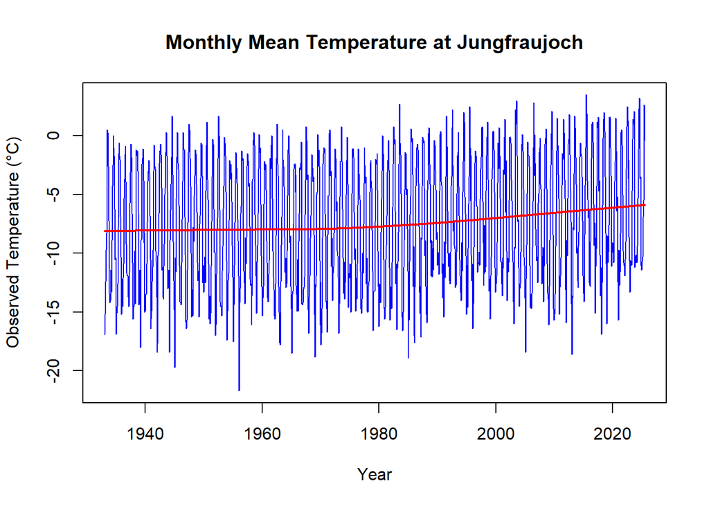

```r
# Plot observed temp with LOWESS trend
plot(ts_jungfraujoch,
     ylab = "Observed Temperature (°C)",
     xlab = "Year",
     main = "Monthly Mean Temperature at Jungfraujoch",
     col = "blue", lwd = 1)

# Add smoothed trend line
lines(lowess(time(ts_jungfraujoch), ts_jungfraujoch), col = "red", lwd = 2)
```

### 3.0.2 Glacier

```r
ts_mass <- ts(df_glacier$glacier_area_m2,
              start = as.numeric(format(min(df_glacier$obs_end_date), "%Y")),
              end = as.numeric(format(max(df_glacier$obs_end_date), "%Y")),
              frequency = 1)
summary(ts_mass)
```

```
##    Min. 1st Qu.  Median    Mean 3rd Qu.    Max.
##   75.49   83.02   86.56   86.11   87.48   91.81
```

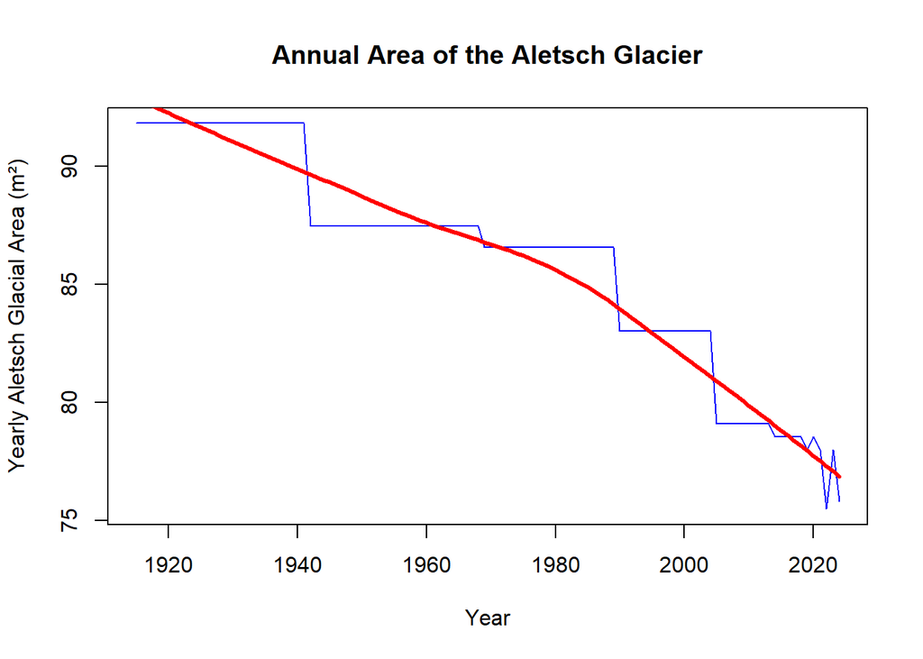

```r
plot(
  ts_mass,
  ylab = "Yearly Aletsch Glacial Area (m²)",
  xlab = "Year",
  main = "Annual Area of the Aletsch Glacier",
  col = "blue",
  lwd = 1,
)
lines(lowess(ts_mass), col = "red", lwd = 3)
```

In the last 100 years, the Aletsch Glacier, the largest glacier in the Alps, has already reduced 18% in area. The decline is especially steep in recent decades, reflecting the intensifying effects of rising temperatures. The shrinking glacier not only represents a loss of ice mass but also signals a reduced capacity to provide stable meltwater flow in the future.

```r
print("Summary Statistics of Winter mass balance (mmwe) values:")
```

```
## [1] "Summary Statistics of Winter mass balance (mmwe) values:"
```

```r
summary(df_glacier$winter_mass_balance_mmwe)
```

```
##    Min. 1st Qu.  Median    Mean 3rd Qu.    Max.
##      82     927    1256    1219    1478    2100
```

```r
print("Summary Statistics of Summer mass balance (mmwe) values:")
```

```
## [1] "Summary Statistics of Summer mass balance (mmwe) values:"
```

```r
summary(df_glacier$summer_mass_balance_mmwe)
```

```
##    Min. 1st Qu.  Median    Mean 3rd Qu.    Max.
##   -3959   -2176   -1682   -1785   -1262    -329
```

The summary statistics reveal a clear asymmetry between the two seasons: winter mass balance values are consistently positive, ranging from about 80 to 2100 mm w.e., indicating steady accumulation of snow and ice. By contrast, summer mass balance values are consistently negative, with losses reaching nearly –4000 mm w.e. The seasonal mass balance suggests that summer ablation far outweighs winter accumulation, making glacier retreat inevitable under rising temperatures. We hypothesize that this imbalance could lead to higher short-term summer flows in the Massa River.

### 3.0.3 Massa Waterlevel

```r
summary(waterlevel_ts)
```

```
##    Min. 1st Qu.  Median    Mean 3rd Qu.    Max.
##    1440    1440    1447    1445    1448    1449
```

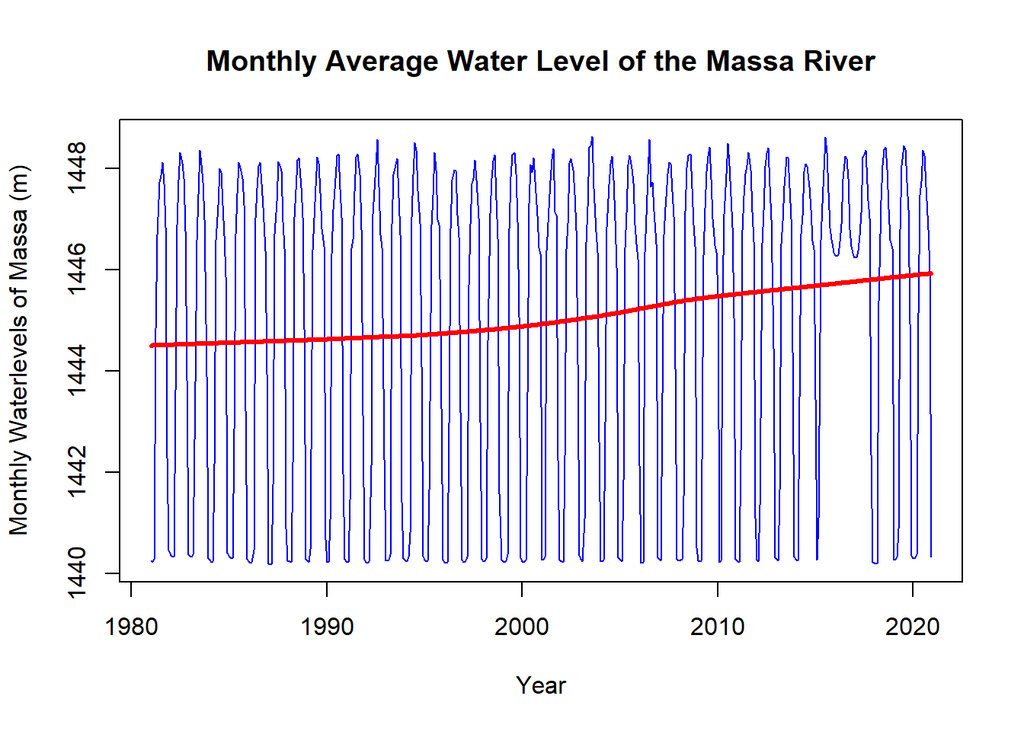

```r
plot(
  waterlevel_ts,
  ylab = "Monthly Waterlevels of Massa (m)",
  xlab = "Year",
  main = "Monthly Average Water Level of the Massa River",
  col = "blue",
  lwd = 1,
)
lines(lowess(waterlevel_ts), col = "red", lwd = 3)
```

The Massa River exhibits distinct seasonal fluctuations, with peak water levels corresponding to summer melt periods. The long-term trend shows a slight increase in average water levels, likely due to intensified glacier melt under rising temperatures. While this suggests that warming has temporarily enhanced summer flows, such increases are not sustainable as the glacier continues to diminish. In the long run, reduced glacial mass will lead to declining water availability.

### 3.0.4 Massa Water Discharge

```r
summary(ts_watervolume_monthly)
```

```
##    Min. 1st Qu.  Median    Mean 3rd Qu.    Max.
##  0.1986  0.5925  3.5255 14.5295 26.8135 71.3535
```

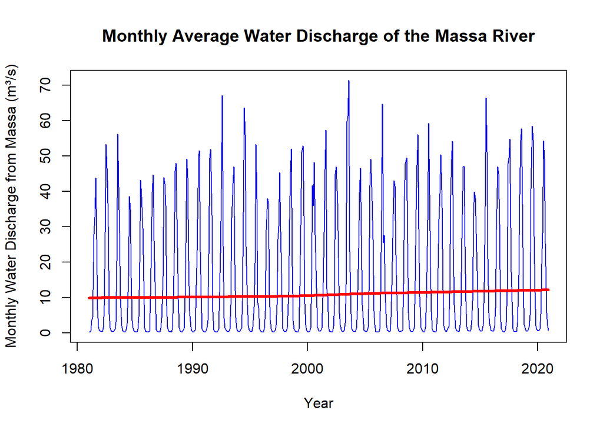

```r
plot(
  ts_watervolume_monthly,
  ylab = "Monthly Water Discharge from Massa (m³/s)",
  xlab = "Year",
  main = "Monthly Average Water Discharge of the Massa River",
  col = "blue",
  lwd = 1,
)
lines(lowess(ts_watervolume_monthly), col = "red", lwd = 3)
```

Looking at the summary statistics, the skewed distribution (median = 3.53 m³/s, mean > median) indicates that discharge is low for much of the year, punctuated by high-flow events during the melt season. The plot of Monthly Average Water Discharge of the Massa River shows pronounced seasonal variation in water discharge, with sharp peaks during the summer months. This pattern reflects the strong influence of glacial melt on the river’s hydrology. The long-term trend (red line) suggests a modest increase in discharge over time, consistent with intensified glacial melting.

### 3.0.5 Brig Precipitation

```r
summary(rain_ts)
```

```
##    Min. 1st Qu.  Median    Mean 3rd Qu.    Max.
##    0.10   26.30   46.20   59.12   79.55  300.10
```

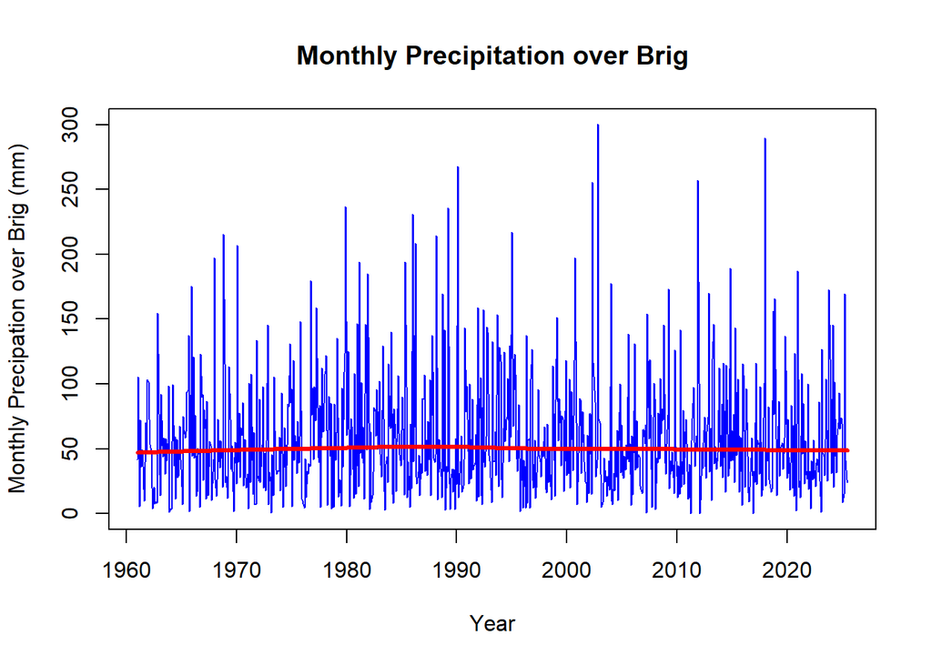

```r
plot(
  rain_ts,
  ylab = "Monthly Precipation over Brig (mm)",
  xlab = "Year",
  main = "Monthly Precipitation over Brig",
  col = "blue",
  lwd = 1,
)
lines(lowess(rain_ts), col = "red", lwd = 3)
```

Precipitation data for Brig reveal considerable short-term variability but no strong long-term trend. This relative stability indicates that changes in precipitation patterns are unlikely to explain observed changes in river levels. Other factors, such as glacier melt influenced by rising temperatures, may therefore play a more significant role.

## 3.1 Implications

Taken together, the exploratory findings suggest several interconnected impacts of climate change on Brig’s water resources:

- The exploratory analysis suggests that rising temperatures accelerate glacier retreat, reducing long-term ice reserves.
- In the short term, this enhances Massa River water levels, increasing the risk of high summer flows and potential flooding.
- In the long term, continued glacier shrinkage could possibly weaken the buffering capacity of meltwater, threatening water security for Brig despite stable precipitation.

**Hypothesis**: Glacier retreat has a dual effect on downstream hydrology — initially increasing river discharge extremes due to enhanced melt, but ultimately reducing baseflow and water availability as glacier storage diminishes. This process may already be detectable in discharge anomalies observed after 2015.

These hypotheses form the basis for subsequent ARIMAX and EVT modelling, which are used to formally test the extent and significance of climate-driven impacts on Brig’s population.

# 4 Stationarity

The time series were checked for stationarity by inspecting their Autocorrelation Functions (ACF) and Partial Autocorrelation Functions (PACF). To further investigate the structure of the data, we applied Seasonal-Trend decomposition using Loess (STL). STL separates the time series into trend, seasonal and remainder components, which is useful to identify and remove seasonality and trends before time series modelling. Different variations of the s.window parameter were tested to control the smoothness of the seasonal component. Additionaly the t.window parameter was used to control the smoothing of the trend component.

## 4.1 Temperature Jungfraujoch

### 4.1.1 Annual mean temperature

**Jungfraujoch temperature annual**

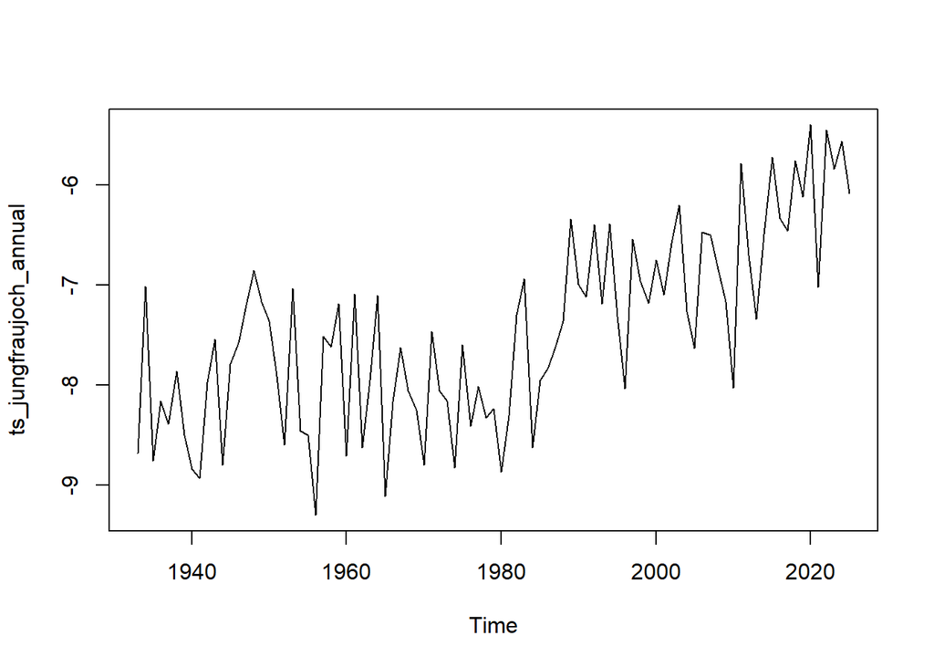

```r
plot(ts_jungfraujoch_annual)
```

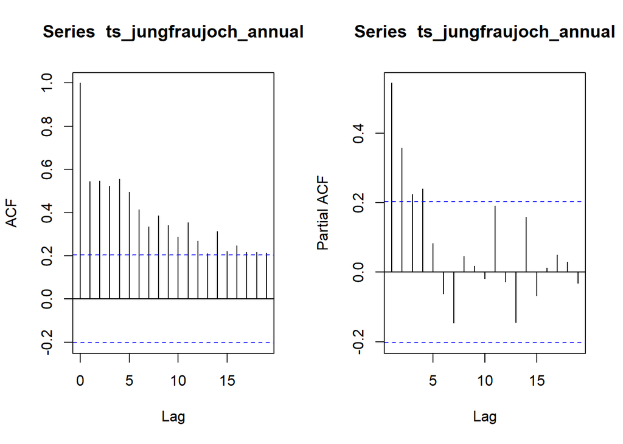

```r
# acf and pacf
par(mfrow = c(1,2))
acf(ts_jungfraujoch_annual)
pacf(ts_jungfraujoch_annual)
```

```r
# adf
adf.test(ts_jungfraujoch_annual)
```

```
##
##  Augmented Dickey-Fuller Test
##
## data:  ts_jungfraujoch_annual
## Dickey-Fuller = -2.1023, Lag order = 4, p-value = 0.5341
## alternative hypothesis: stationary
```

After differencing the plot shows no visible trend. The ACF decays quickly while the PACF shows a mean reversion (negative partial autocorrelation) with a remaining AR process. The ADF test no indicates stationarity as well (p = .01).

**Jungfraujoch temperature annual after differencing**

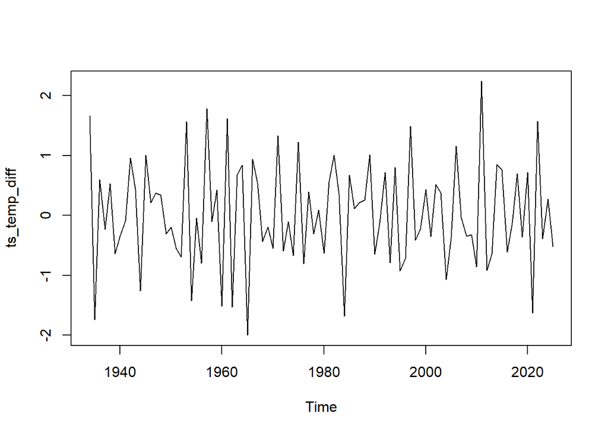

```r
# differencing
ts_temp_diff <- diff(ts_jungfraujoch_annual)
# plot ts
plot(ts_temp_diff)
```

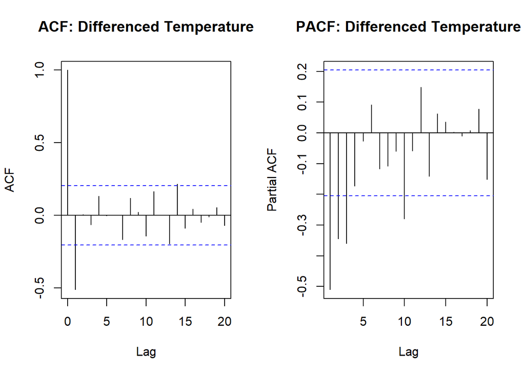

```r
# check ACF and PACF of differenced series
par(mfrow=c(1,2))
acf(ts_temp_diff, main="ACF: Differenced Temperature", lag.max=20)
pacf(ts_temp_diff, main="PACF: Differenced Temperature", lag.max=20)
```

```r
# check adf
adf.test(ts_temp_diff)
```

```
##
##  Augmented Dickey-Fuller Test
##
## data:  ts_temp_diff
## Dickey-Fuller = -6.1987, Lag order = 4, p-value = 0.01
## alternative hypothesis: stationary
```

### 4.1.2 Monthly mean temperature

The ACF shows a strong seasonal pattern reflecting the seasonal temperature cycle. The PACF indicates that monthly mean temperatures are influenced by the previous month (lag 1). Then shows a negative connection for the next few months (lags 2 to 6) and a positive connection again (lags 8 to 13). This is likely due to temperature changes following a seasonal pattern, where each month corresponds to a specific period (e.g. season). Despite the clear seasonality in the monthly temperature the ADF test indicates stationarity (p = .01).

**Jungfraujoch ACF and PACF**

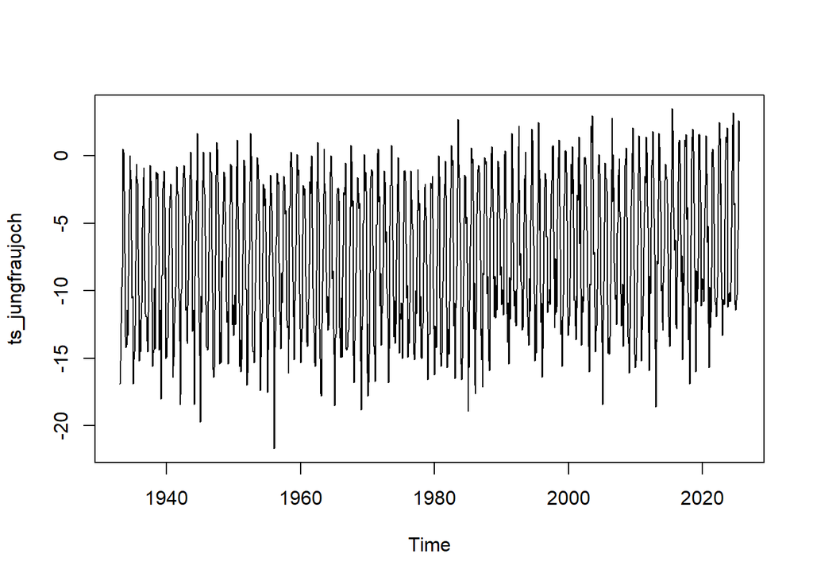

```r
# plot
plot(ts_jungfraujoch)
```

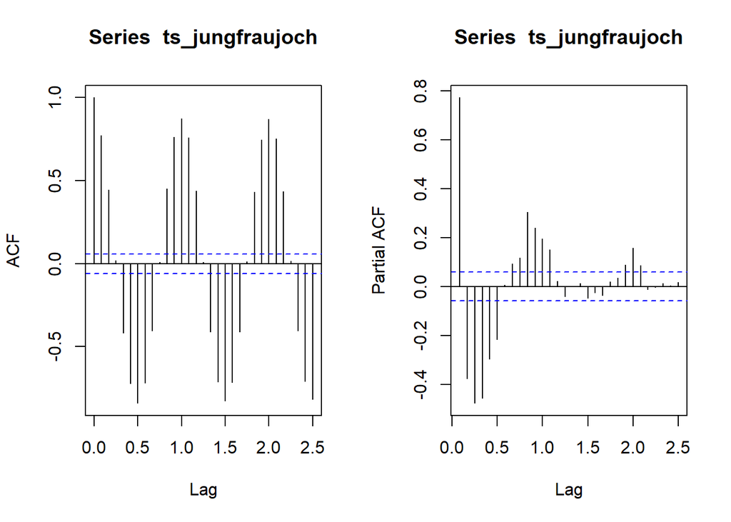

```r
# acf and pacf
par(mfrow=c(1,2))
acf(ts_jungfraujoch) # acf indicates seasonality
pacf(ts_jungfraujoch) # damped sinusoid
```

```r
# adf
adf.test(ts_jungfraujoch)
```

```
##
##  Augmented Dickey-Fuller Test
##
## data:  ts_jungfraujoch
## Dickey-Fuller = -8.7828, Lag order = 10, p-value = 0.01
## alternative hypothesis: stationary
```

After testing different windows for STL decomposition, we observed that larger seasonal windows slightly reduced autocorrelations in the remainder, whereas the PACF improved notably when using a large trend window. An s.window of 37 and a t.window of 121 showed the most satisfying result. The ADF test was used again to formally check stationarity of the remainder. The significant result (p < .01) indicates stationarity.

**Jungfraujoch Temperature STL Decomposition**

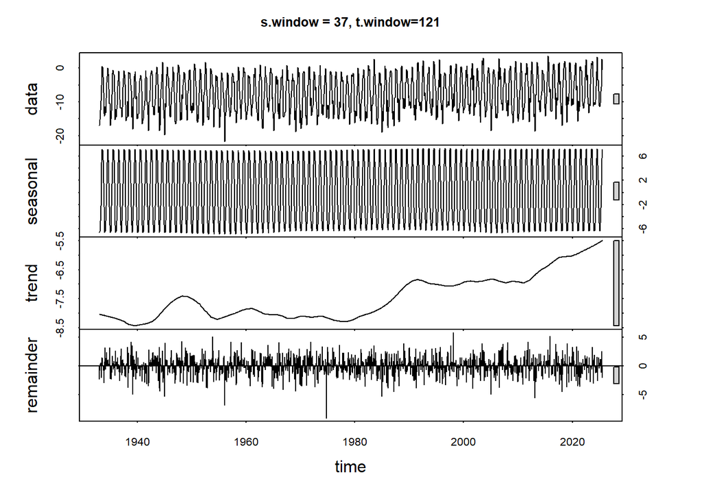

```r
# decomposition with stl
# ts_jungfraujoch_stl <- stl(ts_jungfraujoch, s.window = "periodic") # assumes strong, stable seasonality
# plot(ts_jungfraujoch_stl, main = "s.window periodic")
# ts_jungfraujoch_stl_13 <- stl(ts_jungfraujoch, s.window = 13) # 1 year smooth
# plot(ts_jungfraujoch_stl_13, main = "s.window = 13")
# ts_jungfraujoch_stl_25 <- stl(ts_jungfraujoch, s.window = 25) # 2 year smooth
# plot(ts_jungfraujoch_stl_25, main = "s.window = 25")
# ts_jungfraujoch_stl_37 <- stl(ts_jungfraujoch, s.window = 37) # 3 year smooth
# plot(ts_jungfraujoch_stl_37, main = "s.window = 37")
ts_jungfraujoch_stl_37_121 <- stl(ts_jungfraujoch, s.window = 37, t.window=121) # 3 year smooth
plot(ts_jungfraujoch_stl_37_121, main = "s.window = 37, t.window=121")
```

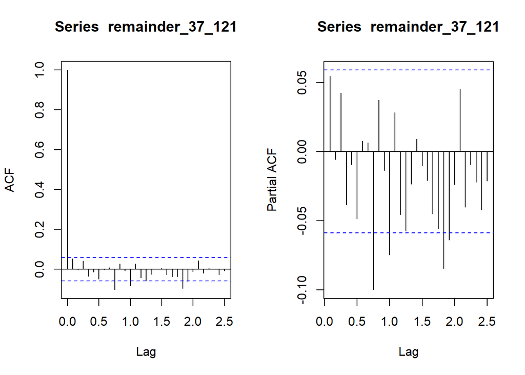

```r
# ts_jungfraujoch_stl_49 <- stl(ts_jungfraujoch, s.window = 49)
# plot(ts_jungfraujoch_stl_49)

# remainder_periodic <- ts_jungfraujoch_stl$time.series[, "remainder"]
# acf(remainder_periodic, main = "ACF of STL remainder, periodic")
# pacf(remainder_periodic, main = "PACF of STL remainder, periodic")
#
# remainder_13 <- ts_jungfraujoch_stl_13$time.series[, "remainder"]
# acf(remainder_13, main = "ACF of STL remainder, s.window = 13")
# pacf(remainder_13, main = "PACF of STL remainder, s.window = 13")
#
# remainder_25 <- ts_jungfraujoch_stl_25$time.series[, "remainder"]
# acf(remainder_25, main="ACF of STL remainder, s.window = 25")
# pacf(remainder_25, main = "PACF of STL remainder, s.window = 25")
#
# remainder_37 <- ts_jungfraujoch_stl_37$time.series[, "remainder"]
# acf(remainder_37, main = "ACF of STL remainder, s.window = 37") # ACF lags 2 and 5 persist
# pacf(remainder_37, main = "PACF of STL remainder, s.window = 37")

remainder_37_121 <- ts_jungfraujoch_stl_37_121$time.series[, "remainder"]
par(mfrow=c(1,2))
acf(remainder_37_121)
pacf(remainder_37_121) # no change compared to without t.window
```

```r
# augmented dickey fuller test to check stationarity formally
adf.test(remainder_37_121)
```

```
##
##  Augmented Dickey-Fuller Test
##
## data:  remainder_37_121
## Dickey-Fuller = -10.812, Lag order = 10, p-value = 0.01
## alternative hypothesis: stationary
```

For further modelling a data frame containing the components of the decomposed time series as well as the observed data was created and saved.

**Jungfraujoch create cleaned data frame**

```r
# Extract components
components <- ts_jungfraujoch_stl_37_121$time.series
# Create a time index (Date or Year-Month depending on your ts object)
dates <- time(ts_jungfraujoch)
# Build a data frame
df_jungfraujoch_processed <- data.frame(
  date       = dates,
  observed   = as.numeric(ts_jungfraujoch),
  trend      = as.numeric(components[, "trend"]),
  seasonal   = as.numeric(components[, "seasonal"]),
  remainder  = as.numeric(components[, "remainder"])
)
# create processed data file
write.csv(df_jungfraujoch_processed, "../data/processed/jungfraujoch_temperature.csv", row.names = FALSE)
# RDS
saveRDS(df_jungfraujoch_processed, "../data/processed/jungfraujoch_temperature.rds")
```

## 4.2 Glacier Mass Balance

### 4.2.1 Annual glacier mass balance

It looks like there is a potential downward trend starting around 2010. The ACF and PACF indicate stationarity, whereas the ADF test is not significant (p > .05) suggesting non-stationrarity. Since glacier-mass balance represents an annual physical balance (with fluctuations around ~ 0) we decided not to difference it.

**Glacier mass balance annually ACF and PACF**

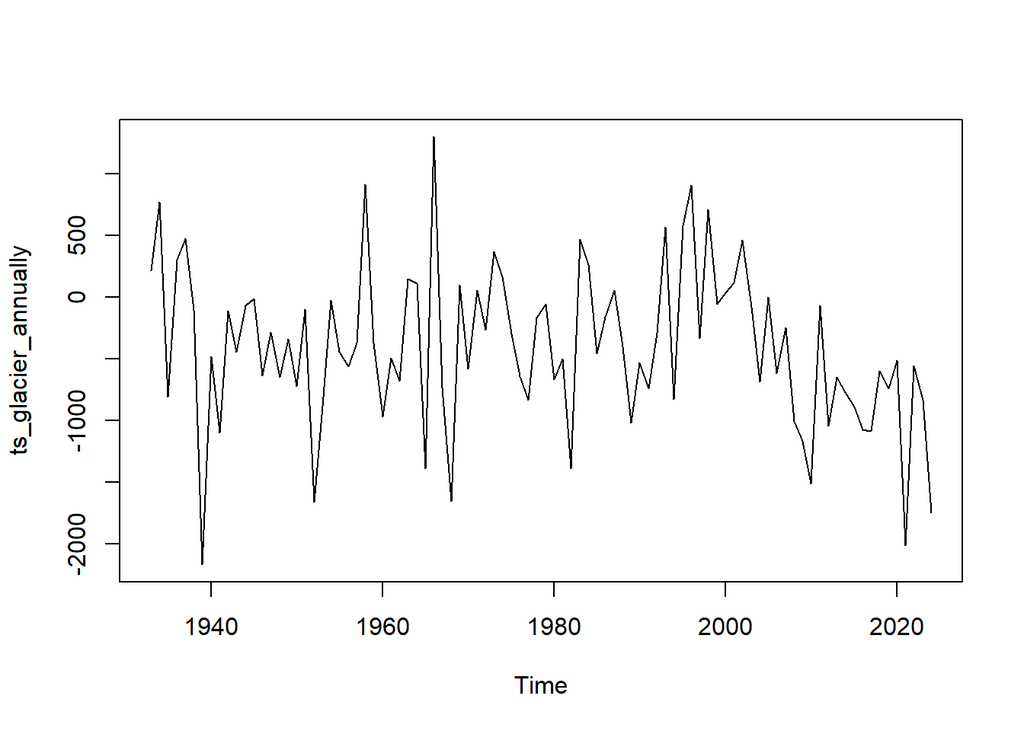

```r
# plot
plot(ts_glacier_annually)
```

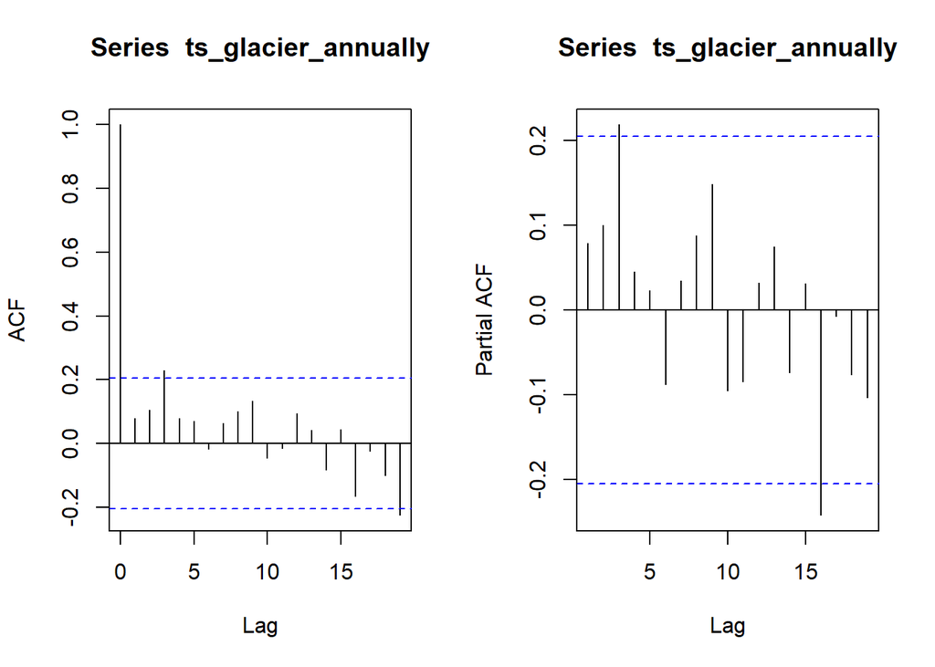

```r
# ACF and PACF
par(mfrow=c(1,2))
acf(ts_glacier_annually)
pacf(ts_glacier_annually)
```

```r
# adf
adf.test(ts_glacier_annually)
```

```
##
##  Augmented Dickey-Fuller Test
##
## data:  ts_glacier_annually
## Dickey-Fuller = -2.9184, Lag order = 4, p-value = 0.1977
## alternative hypothesis: stationary
```

### 4.2.2 Monthly glacier mass balance

```r
ts_glacier <- ts(df_glacier_monthly$mass_balance_monthly, frequency = 12,
                 start = c(1933, 1))
ts_seasonal <- diff(ts_glacier, lag = 12)
adf_seasonal <- ur.df(ts_seasonal, type = "drift", selectlags = "AIC")
summary(adf_seasonal)
```

```
##
## ###############################################
## # Augmented Dickey-Fuller Test Unit Root Test #
## ###############################################
##
## Test regression drift
##
##
## Call:
## lm(formula = z.diff ~ z.lag.1 + 1 + z.diff.lag)
##
## Residuals:
##      Min       1Q   Median       3Q      Max
## -2469.83   -75.53    -1.87    75.43  2389.63
##
## Coefficients:
##             Estimate Std. Error t value Pr(>|t|)
## (Intercept) -0.47066    7.24848  -0.065    0.948
## z.lag.1     -0.92164    0.04173 -22.088   <2e-16 ***
## z.diff.lag  -0.01212    0.03055  -0.397    0.692
## ---
## Signif. codes:  0 '***' 0.001 '**' 0.01 '*' 0.05 '.' 0.1 ' ' 1
##
## Residual standard error: 237.7 on 1072 degrees of freedom
## Multiple R-squared:  0.4663, Adjusted R-squared:  0.4654
## F-statistic: 468.4 on 2 and 1072 DF,  p-value: < 2.2e-16
##
##
## Value of test-statistic is: -22.0876 243.9303
##
## Critical values for test statistics:
##       1pct  5pct 10pct
## tau2 -3.43 -2.86 -2.57
## phi1  6.43  4.59  3.78
```

The original monthly glacier series had strong trend and seasonal components and was not stationary. After seasonal differencing (lag=12) the series appears stationary: The ADF test on the seasonally-differenced series strongly rejects a unit root since the test statistic (τ = –22.09) is far below the 1% critical value (–3.43), confirming that the series is stationary.

### 4.2.3 STL Decomposition

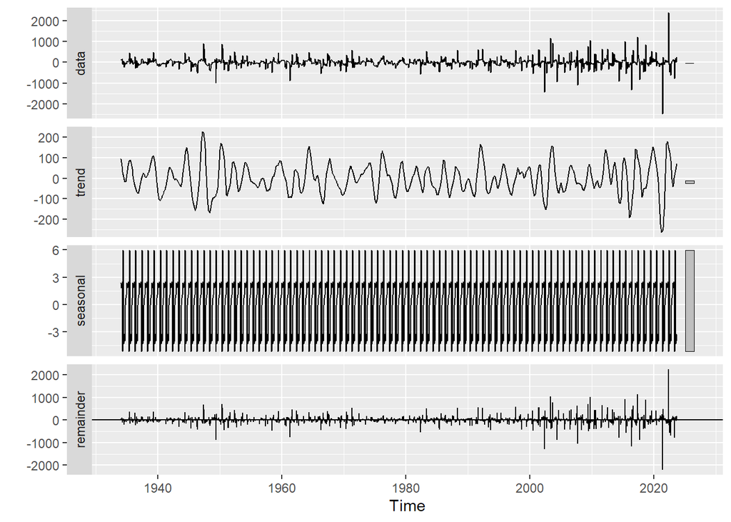

```r
decomp <- stl(ts_seasonal, s.window = "periodic")
autoplot(decomp)
```

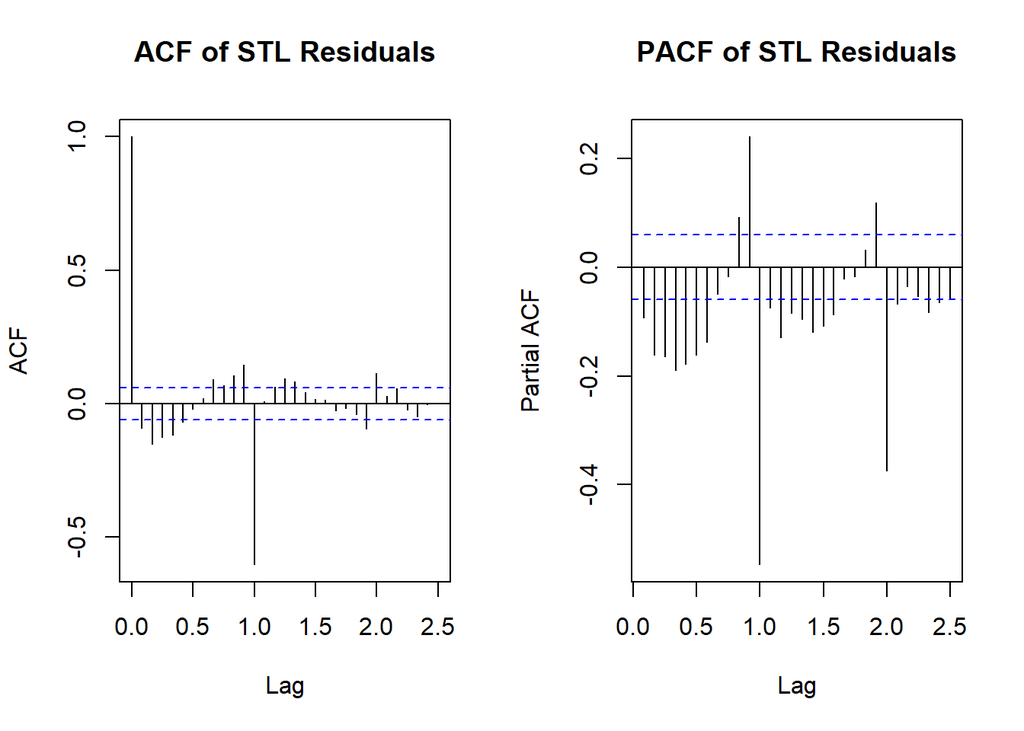

```r
## Extract residuals
residuals_stl <- decomp$time.series[,"remainder"]

## Plot ACF and PACF of residuals
par(mfrow=c(1,2))
acf(residuals_stl, main="ACF of STL Residuals", na.action=na.pass)
pacf(residuals_stl, main="PACF of STL Residuals", na.action=na.pass)
```

```r
## adding components from stl decomp to the df
## First 12 values are NA as seasonal decomp was done with lag=12
df_glacier_monthly$trend <- c(rep(NA, 12), as.numeric(decomp$time.series[,"trend"]))
df_glacier_monthly$seasonal <- c(rep(NA, 12), as.numeric(decomp$time.series[,"seasonal"]))
df_glacier_monthly$deterministic <- c(rep(NA, 12), as.numeric(decomp$time.series[,"trend"]) + as.numeric(decomp$time.series[,"seasonal"]))
df_glacier_monthly$stochastic <- c(rep(NA, 12), as.numeric(decomp$time.series[,"remainder"]))

saveRDS(df_glacier_monthly, "../data/processed/glacier_monthly_processed.rds")
```

## 4.3 Precipitation Brig

### 4.3.1 Annual Precipitation

For total annual precipiation the ACF and PACF as well as the ADF test indicate stationarity (p = .01).

**Brig rain annual**

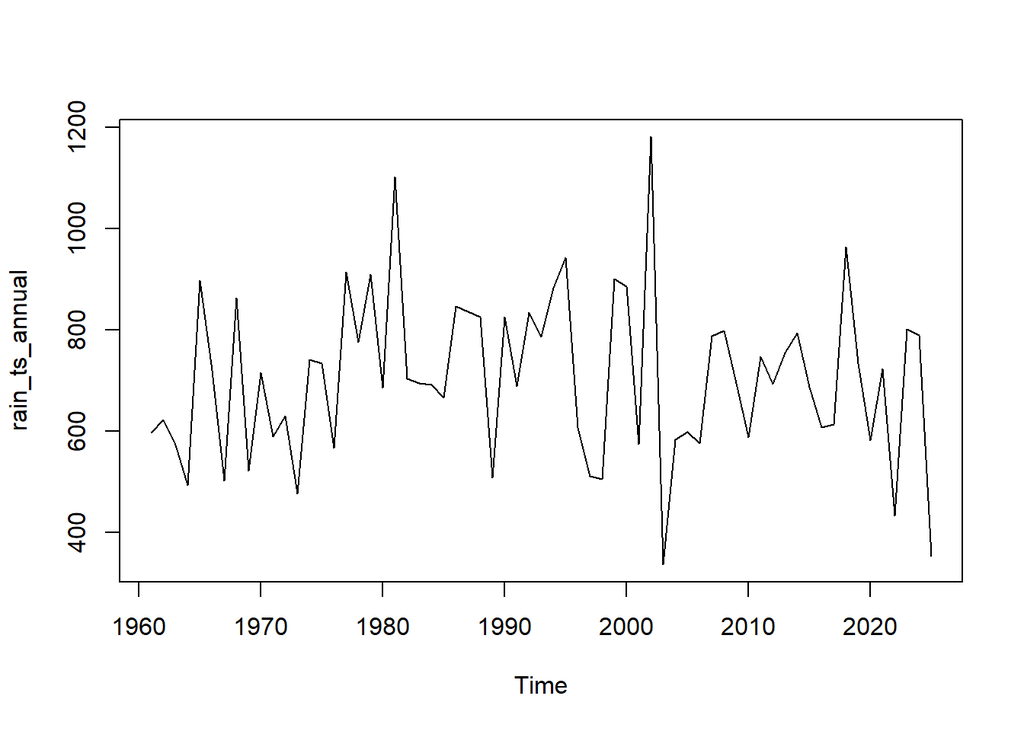

```r
plot(rain_ts_annual)
```

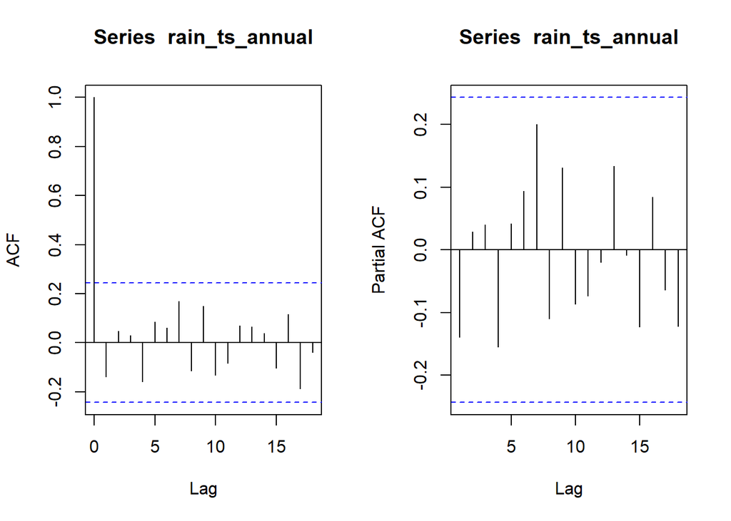

```r
# acf and pacf
par(mfrow = c(1,2))
acf(rain_ts_annual)
pacf(rain_ts_annual)
```

```r
# adf
adf.test(rain_ts_annual)
```

```
##
##  Augmented Dickey-Fuller Test
##
## data:  rain_ts_annual
## Dickey-Fuller = -4.6546, Lag order = 3, p-value = 0.01
## alternative hypothesis: stationary
```

### 4.3.2 Monthly - Stationarity with stl

**Brig rain stl**

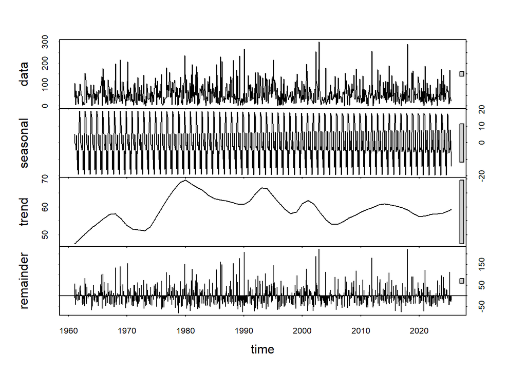

```r
#stl_decompose of brig rain
stl_1 <- stl(rain_ts, s.window =122, t.window=115)
plot(stl_1)
```

```r
remainder_stl1 <- stl_1$time.series[,"remainder"]
adf.test(remainder_stl1)
```

```
##
##  Augmented Dickey-Fuller Test
##
## data:  remainder_stl1
## Dickey-Fuller = -9.5108, Lag order = 9, p-value = 0.01
## alternative hypothesis: stationary
```

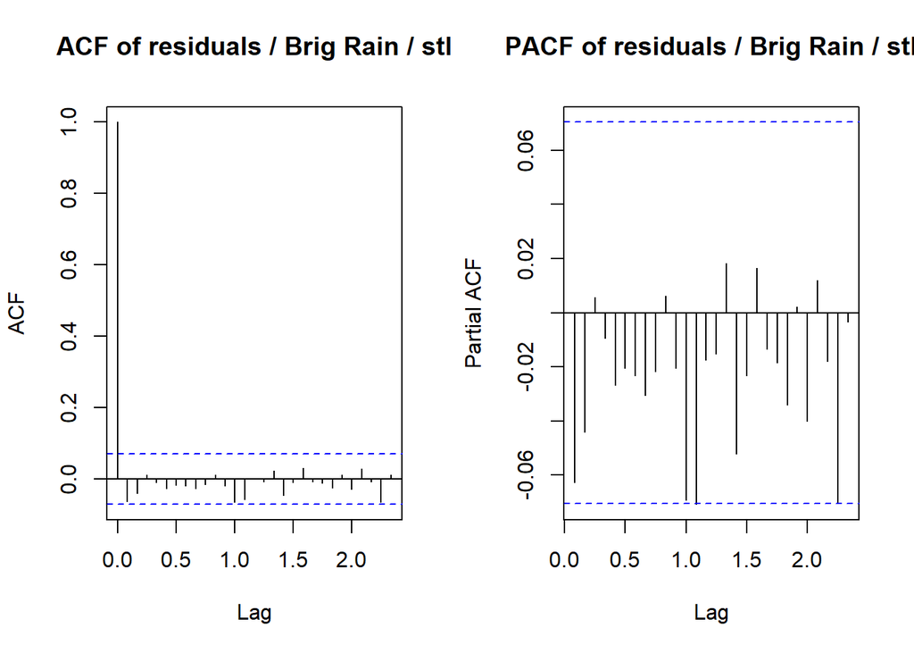

```r
par(mfrow=c(1,2))
acf(remainder_stl1, main = "ACF of residuals / Brig Rain / stl")
pacf(remainder_stl1, main = "PACF of residuals / Brig Rain / stl")
```

**Brig creating dataframe with stl prepared data**

```r
#Creating dataframe of the prepared data
rain_decomp_df <- data.frame(
  Date      = as.Date(as.yearmon(time(rain_ts))),  # month data
  Original  = as.numeric(rain_ts),                 # Raw Data
  Trend     = stl_1$time.series[,"trend"],         # Trend-Componente
  Seasonal  = stl_1$time.series[,"seasonal"],      # Saisonal-Component
  Remainder = stl_1$time.series[,"remainder"]      # Remainder
)

head(rain_decomp_df)  # for checking
```

```
##         Date Original    Trend   Seasonal  Remainder
## 1 1961-01-01     42.1 46.73305  5.3253259  -9.958381
## 2 1961-02-01    105.6 46.89941 -0.1171743  58.817762
## 3 1961-03-01      5.4 47.06577 -1.3699439 -40.295827
## 4 1961-04-01     72.3 47.23213 -4.4035876  29.471459
## 5 1961-05-01     35.9 47.39849  4.5069034 -16.005390
## 6 1961-06-01     49.3 47.56484 -4.1379366   5.873092
```

```r
saveRDS(rain_decomp_df, file = "rain_decomposition.rds")
```

## 4.4 Massa River

### 4.4.1 Waterlevel

The time series plot reveals a strong seasonal pattern, with peak waterlevels occurring annually. The observed values range approximately between 1440 m and 1449 m above sea level, reflecting typical seasonal fluctuations driven by snowmelt and precipitation. The ACF shows significant spikes at lag 12 and its multiples, confirming strong annual seasonality. The PACF shows a high spike at lag 1, indicating a strong influence of the previous month on the current month’s water level. We first applied STL with a “periodic” seasonal window setting. This initial decomposition revealed a strong and stable seasonal component recurring annually, as well as a trend component (particularly visibile after the year 2000). However, the ACF and PACF of the remainder component still exhibited notable autocorrelations.

To improve the decomposition, we tested various parameter settings for both the seasonal window (s.window) and the trend window (t.window). Specifically, we compared s.window values of 13, 35, and “periodic” to adjust the smoothness of the seasonal component, while varying t.window values (e.g., 121) to control the smoothing of the trend. The optimal decomposition was achieved using s.window = 35 and t.window = 121, which resulted in the most satisfactory balance in the ACF and PACF of the remainder component.

**massa river waterlevel stationarity**

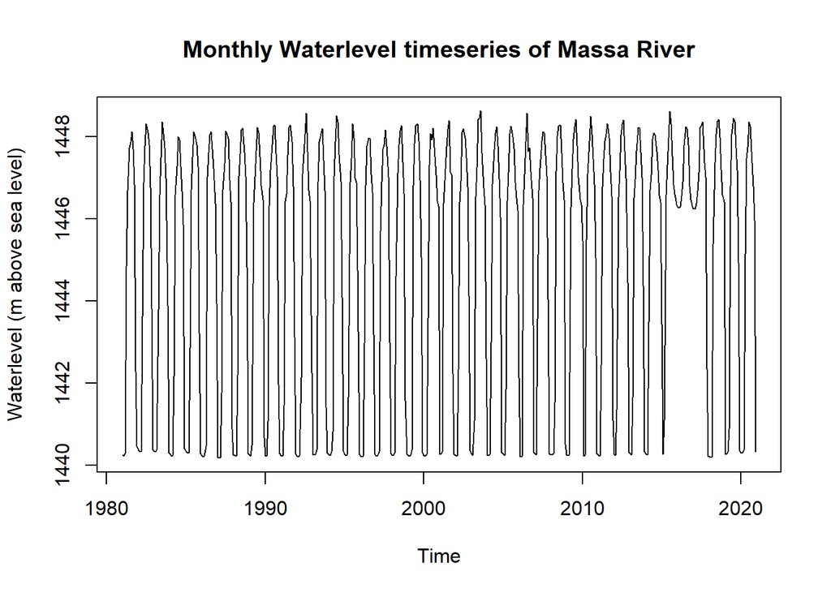

```r
# create ts object for waterlevel
waterlevel_ts <- ts(df_monthly$waterlevel_m,
                    start = c(year(min(df_monthly$date_yyyymmdd)),
                              month(min(df_monthly$date_yyyymmdd))),
                    frequency = 12)

plot(waterlevel_ts, main = "Monthly Waterlevel timeseries of Massa River",
     ylab = "Waterlevel (m above sea level)", xlab = "Time")
```

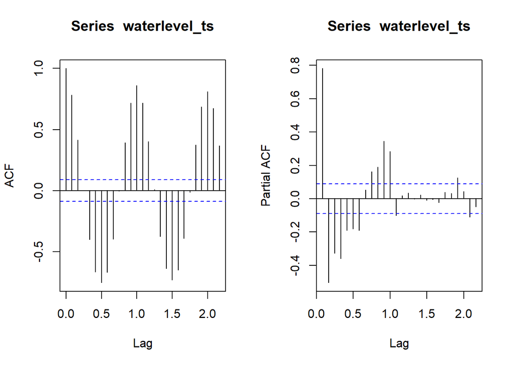

```r
par(mfrow = c(1, 2))
acf(waterlevel_ts)
pacf(waterlevel_ts)
```

```r
adf.test(waterlevel_ts) #p-value 0.01 (<0.05) so according to ADF stationary
```

```
##
##  Augmented Dickey-Fuller Test
##
## data:  waterlevel_ts
## Dickey-Fuller = -14.053, Lag order = 7, p-value = 0.01
## alternative hypothesis: stationary
```

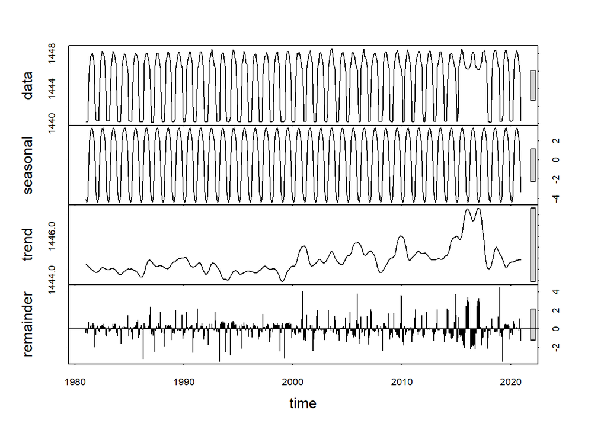

```r
# first STL decomposition
stl_decomp <- stl(waterlevel_ts, s.window = "periodic")
plot(stl_decomp)
```

```r
remainder_waterlevel <- stl_decomp$time.series[,"remainder"]
adf.test(remainder_waterlevel) # p-value 0.01
```

```
##
##  Augmented Dickey-Fuller Test
##
## data:  remainder_waterlevel
## Dickey-Fuller = -13.35, Lag order = 7, p-value = 0.01
## alternative hypothesis: stationary
```

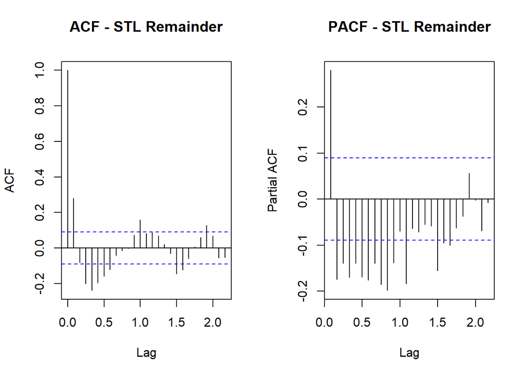

```r
par(mfrow = c(1, 2))
acf(remainder_waterlevel, main = "ACF - STL Remainder")
pacf(remainder_waterlevel, main = "PACF - STL Remainder")
```

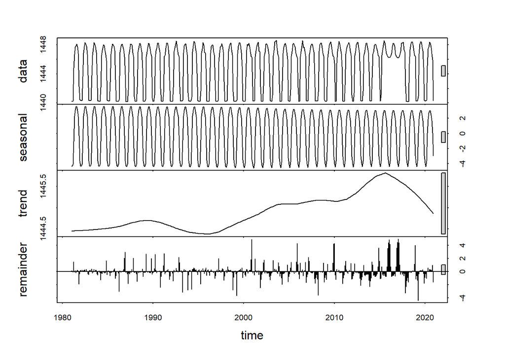

```r
### TESTING s.window and t.window
#s.window=13, t.window=default
# stl_1 <- stl(waterlevel_ts, s.window = 13)
# plot(stl_1)
#
# remainder_stl1 <- stl_1$time.series[,"remainder"]
# adf.test(remainder_stl1) # p-value 0.01
# acf(remainder_stl1, main = "ACF - STL Remainder")
# pacf(remainder_stl1, main = "PACF - STL Remainder")
# par(mfrow = c(1, 1))
#
# #s.window=13, t.window=121
# stl_2 <- stl(waterlevel_ts, s.window = 13, t.window = 121)
# plot(stl_2)
#
# remainder_stl2 <- stl_2$time.series[,"remainder"]
# adf.test(remainder_stl2) # p-value 0.01
# acf(remainder_stl2, main = "ACF - STL Remainder")
# pacf(remainder_stl2, main = "PACF - STL Remainder")
# par(mfrow = c(1, 1))
#
# #s.window="periodic", t.window=121
# stl_3 <- stl(waterlevel_ts, s.window = "periodic", t.window = 121)
# plot(stl_3)
#
# remainder_stl3 <- stl_3$time.series[,"remainder"]
# adf.test(remainder_stl3) # p-value 0.01
# acf(remainder_stl3, main = "ACF - STL Remainder")
# pacf(remainder_stl3, main = "PACF - STL Remainder")
# par(mfrow = c(1, 1))
#
# #s.window="periodic", t.window=121
# stl_4 <- stl(waterlevel_ts, s.window = 35)
# plot(stl_4)
#
# remainder_stl4 <- stl_4$time.series[,"remainder"]
# adf.test(remainder_stl4) # p-value 0.01
# acf(remainder_stl4, main = "ACF - STL Remainder")
# pacf(remainder_stl4, main = "PACF - STL Remainder")
# par(mfrow = c(1, 1))

#s.window=35, t.window=121
stl_5 <- stl(waterlevel_ts, s.window = 35, t.window=121)
plot(stl_5)
```

```r
remainder_stl5 <- stl_5$time.series[,"remainder"]
adf.test(remainder_stl5) # p-value 0.01
```

```
##
##  Augmented Dickey-Fuller Test
##
## data:  remainder_stl5
## Dickey-Fuller = -8.2753, Lag order = 7, p-value = 0.01
## alternative hypothesis: stationary
```

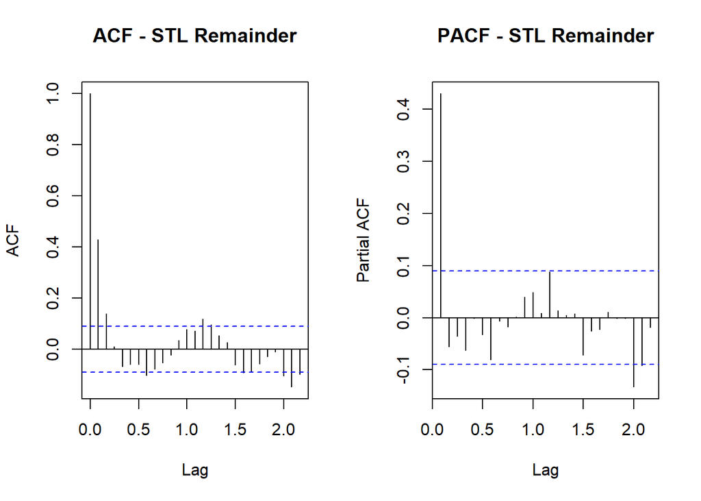

```r
acf(remainder_stl5, main = "ACF - STL Remainder")
pacf(remainder_stl5, main = "PACF - STL Remainder")
```

```r
par(mfrow = c(1, 1))
```

For further modelling a data frame containing the decomposed time series components alongside the original observations was created and saved. This structured dataset separates deterministic components (trend + seasonal) from stochastic variations (remainder).

**massa river stl_decompose**

```r
## take decomp with s.window=35, t.window=121 as final decomp and create df
stl_result <- stl(waterlevel_ts, s.window = 35, t.window=121)
trend_comp <- as.numeric(stl_result$time.series[,"trend"])
seasonal_comp <- as.numeric(stl_result$time.series[,"seasonal"])
remainder_comp <- as.numeric(stl_result$time.series[,"remainder"])

# Create the det_stoch dataframe
det_stoch <- data.frame(
  year_month = format(df_monthly$date_yyyymmdd, "%b %Y"),
  waterlevel_m = df_monthly$waterlevel_m,
  trend = trend_comp,
  seasonal = seasonal_comp,
  deterministic = trend_comp + seasonal_comp,
  stochastic = remainder_comp
)

## save det_stoch df as RDS and CSV
saveRDS(det_stoch, "../data/processed/waterlevel_det_stoch.rds")
# write.csv(det_stoch, "data/processed/waterlevel_det_stoch.csv", row.names = FALSE)
```

### 4.4.2 Water Discharge

#### 4.4.2.1 Monthly average discharge massa timeseries

The original, non-decomposed time series exhibits a pronounced seasonal pattern, with values ranging from 0 to 70 m³/s. This outcome is not unexpected, as the previously analyzed monthly water levels of the Massa River reveal the same phenomenon, expressed in a different metric.

**plotting massa timeseries**

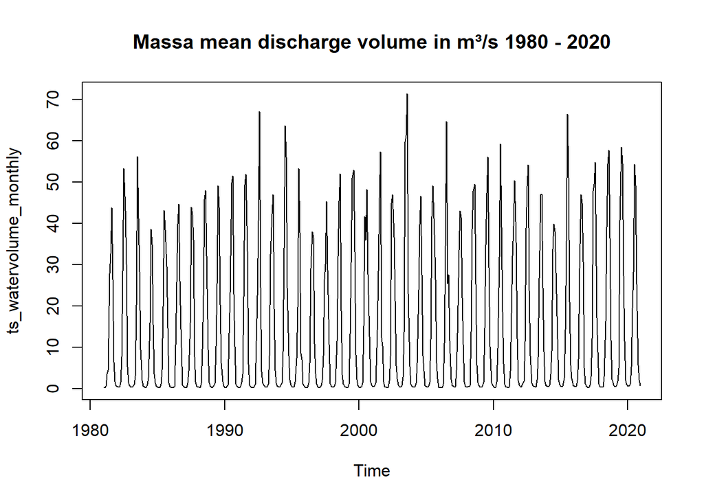

```r
plot(ts_watervolume_monthly, main = "Massa mean discharge volume in m³/s 1980 - 2020")
```